# Modeling and prediction for movies

## Setup

```r
Sys.setlocale('LC_ALL','C')
```

```
## [1] "C"
```

### Load packages

```r
library(dplyr)
library(statsr)
library(GGally)
```

```r
library(corrplot)
library(ggplot2)
```

### Load data

```r
setwd('C:/Users/chanl/Documents/Statistics with R_Coursera/Introduction to Probaility and Data/Statistics-with-R/Linear Regression')
load('movies.RData')
```

## Part 1: Data

This is an observational study which uses a random sample of movie information. Since the data is randomly selected not randomly assigned, we can only make generalizable conclusion to population, not causality. The dataset contains information about 651 movies released before 2016 and there are stored across 32 variables.

## Part 2: Research question

After having a look at the dataset I concluded that I will try to find out the relationship between audience!/s score and movie’s popularity and type.

## Part 3: Exploratory data analysis

# Analyse the Data

Checking the structure of the data using the code below.

```r
str(movies)
```

```
## Classes 'tbl_df', 'tbl' and 'data.frame':    651 obs. of  32 variables:
##  $ title           : chr  "Filly Brown" "The Dish" "Waiting for Guffman" "The Age of Innocence" ...
##  $ title_type      : Factor w/ 3 levels "Documentary",..: 2 2 2 2 2 1 2 2 1 2 ...
##  $ genre           : Factor w/ 11 levels "Action & Adventure",..: 6 6 4 6 7 5 6 6 5 6 ...
##  $ runtime         : num  80 101 84 139 90 78 142 93 88 119 ...
##  $ mpaa_rating     : Factor w/ 6 levels "G","NC-17","PG",..: 5 4 5 3 5 6 4 5 6 6 ...
##  $ studio          : Factor w/ 211 levels "20th Century Fox",..: 91 202 167 34 13 163 147 118 88 84 ...
##  $ thtr_rel_year   : num  2013 2001 1996 1993 2004 ...
##  $ thtr_rel_month  : num  4 3 8 10 9 1 1 11 9 3 ...
##  $ thtr_rel_day    : num  19 14 21 1 10 15 1 8 7 2 ...
##  $ dvd_rel_year    : num  2013 2001 2001 2001 2005 ...
##  $ dvd_rel_month   : num  7 8 8 11 4 4 2 3 1 8 ...
##  $ dvd_rel_day     : num  30 28 21 6 19 20 18 2 21 14 ...
##  $ imdb_rating     : num  5.5 7.3 7.6 7.2 5.1 7.8 7.2 5.5 7.5 6.6 ...
##  $ imdb_num_votes  : int  899 12285 22381 35096 2386 333 5016 2272 880 12496 ...
```

[output cut: 18 more lines]

**Numerical:**

- audience_score (response variable)
- imdb_rating (popularity)
- imdb_num_votes (int, popularity)
- critics_score (popularity)

**Categorical:**

- title_type (type)
- genre (type)
- mpaa_rating (type)
- critics_rating (popularity)
- audience_rating (popularity)
- best_pic_nom (popularity)
- best_pic_win (popularity)

# Getting Data for the model

```r
mv <- movies %>%
  select(audience_score, imdb_rating, imdb_num_votes, critics_score, title_type, genre, mpaa_rating, critics_rating, audience_rating, best_pic_nom, best_pic_win)
```

# Analyze the structure of Model Data

```r
str(mv)
```

```
## Classes 'tbl_df', 'tbl' and 'data.frame':    651 obs. of  11 variables:
##  $ audience_score : num  73 81 91 76 27 86 76 47 89 66 ...
##  $ imdb_rating    : num  5.5 7.3 7.6 7.2 5.1 7.8 7.2 5.5 7.5 6.6 ...
##  $ imdb_num_votes : int  899 12285 22381 35096 2386 333 5016 2272 880 12496 ...
##  $ critics_score  : num  45 96 91 80 33 91 57 17 90 83 ...
##  $ title_type     : Factor w/ 3 levels "Documentary",..: 2 2 2 2 2 1 2 2 1 2 ...
##  $ genre          : Factor w/ 11 levels "Action & Adventure",..: 6 6 4 6 7 5 6 6 5 6 ...
##  $ mpaa_rating    : Factor w/ 6 levels "G","NC-17","PG",..: 5 4 5 3 5 6 4 5 6 6 ...
##  $ critics_rating : Factor w/ 3 levels "Certified Fresh",..: 3 1 1 1 3 2 3 3 2 1 ...
##  $ audience_rating: Factor w/ 2 levels "Spilled","Upright": 2 2 2 2 1 2 2 1 2 2 ...
##  $ best_pic_nom   : Factor w/ 2 levels "no","yes": 1 1 1 1 1 1 1 1 1 1 ...
##  $ best_pic_win   : Factor w/ 2 levels "no","yes": 1 1 1 1 1 1 1 1 1 1 ...
```

# Removing missing data

```r
complete <- complete.cases(mv)
mv <- mv[complete,]
dim(mv)
```

```
## [1] 651  11
```

# Summarize of Model Data

```r
summary(mv)
```

```
##  audience_score   imdb_rating    imdb_num_votes   critics_score
##  Min.   :11.00   Min.   :1.900   Min.   :   180   Min.   :  1.00
##  1st Qu.:46.00   1st Qu.:5.900   1st Qu.:  4546   1st Qu.: 33.00
##  Median :65.00   Median :6.600   Median : 15116   Median : 61.00
##  Mean   :62.36   Mean   :6.493   Mean   : 57533   Mean   : 57.69
##  3rd Qu.:80.00   3rd Qu.:7.300   3rd Qu.: 58301   3rd Qu.: 83.00
##  Max.   :97.00   Max.   :9.000   Max.   :893008   Max.   :100.00
##
##         title_type                 genre      mpaa_rating
##  Documentary : 55   Drama             :305   G      : 19
##  Feature Film:591   Comedy            : 87   NC-17  :  2
##  TV Movie    :  5   Action & Adventure: 65   PG     :118
##                     Mystery & Suspense: 59   PG-13  :133
##                     Documentary       : 52   R      :329
##                     Horror            : 23   Unrated: 50
##                     (Other)           : 60
##          critics_rating audience_rating best_pic_nom best_pic_win
##  Certified Fresh:135    Spilled:275     no :629      no :644
##  Fresh          :209    Upright:376     yes: 22      yes:  7
##  Rotten         :307
##
##
##
##
```

# Data analysis in numerical vaiables

**Numerical:**

- audience_score (response variable)
- imdb_rating (popularity)
- imdb_num_votes (int, popularity)
- critics_score (popularity)

# Summary statistics and distribution of the response variable(audience_score)

```r
ggplot(data = mv, aes(x=audience_score)) +
  geom_histogram(binwidth = 5, color='grey', fill='black')
```

[output not shown]

Moderately left skewd

# Corealation - 1.

```r
num_cols <- c(1,2,3,4)

ggpairs(mv,
        columns = num_cols,
        upper = list(continuous = wrap("cor", size = 5)),
        diag = list(continuous = wrap("barDiag", colour = "darkgrey")),
        lower = list(continuous = wrap("smooth", colour = 'darkgrey')))
```

[output not shown]

Exclude critics_score due to collinearty with imdb_rating

imdb_num_votes variable is not strongly correlated with the other variables

# Distribution of imdb_num_votes

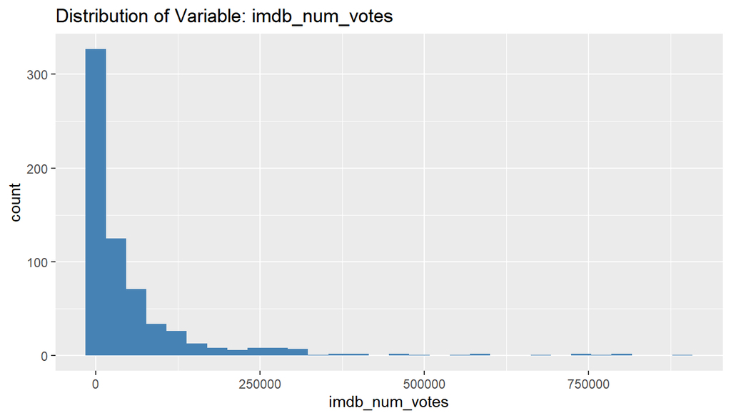

```r
ggplot(mv, aes(imdb_num_votes)) +
  geom_histogram(fill='steelblue')+
  labs(title = 'Distribution of Variable: imdb_num_votes')
```

```r
summary(mv$imdb_num_votes)
```

```
##    Min. 1st Qu.  Median    Mean 3rd Qu.    Max.
##     180    4546   15116   57533   58301  893008
```

: weak correlation

# Change to log

```r
ggplot(mv, aes(log10(imdb_num_votes))) +
  geom_histogram(fill='steelblue')+
  labs(title = 'Distribution of Log Transformed Variable: log10(imdb_num_votes)')
```

[output not shown]

# Relationship between imdb_num_votes (explanatory variable) and audience score (response variable)

```r
ggplot(mv, aes (x = log10(imdb_num_votes), y = audience_score)) +
  geom_point(color = '#56B4E9') +
  geom_smooth(method = 'lm', color = 'darkred', se=FALSE) +
  labs(title = "Scatter Plot of audience_score Vs log10(imdb_num_votes)" )
```

[output not shown]

Moderate positive linear relationship

# Distribution of imdb_rating

```r
ggplot(mv, aes(imdb_rating)) +
  geom_histogram(bins=30, fill='#E69F00')+
  labs(title = 'Distribution of Variable: imdb_rating')
```

[output not shown]

Slightly left skewed

# Relationship between imdb_rating (explanatory variable) and audience score (response variable)

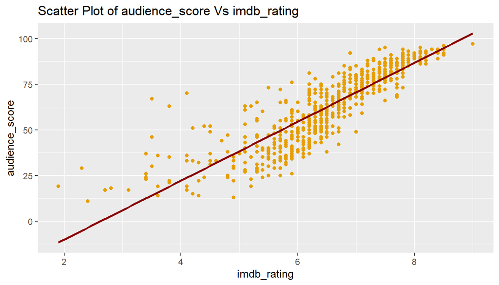

```r
ggplot(mv, aes (x = imdb_rating , y = audience_score)) +
  geom_point(color = '#E69F00') +
  geom_smooth(method = 'lm', color = 'darkred', se=FALSE) +
  labs(title = "Scatter Plot of audience_score Vs imdb_rating" )
```

```r
summary(mv$imdb_rating)
```

```
##    Min. 1st Qu.  Median    Mean 3rd Qu.    Max.
##   1.900   5.900   6.600   6.493   7.300   9.000
```

: Strong positive linear relationship

# Relationship between critics_score (explanatory variable) and audience score (response variable)

```r
ggplot(mv, aes (x = critics_score, y = audience_score)) +
  geom_point(color = '#999999') +
  geom_smooth(method = 'lm', color = 'darkred', se=FALSE) +
  labs(title = "Scatter Plot of audience_score Vs critics_score" )
```

[output not shown]

Strong positive linear relationship, but remove due to collineartly problem

## Data analysis in categorical vaiables

**Categorical:**

- title_type (type)
- genre (type)
- mpaa_rating (type)
- critics_rating (popularity)
- audience_rating (popularity)
- best_pic_nom (popularity)
- best_pic_win (popularity)

# title_type (type)

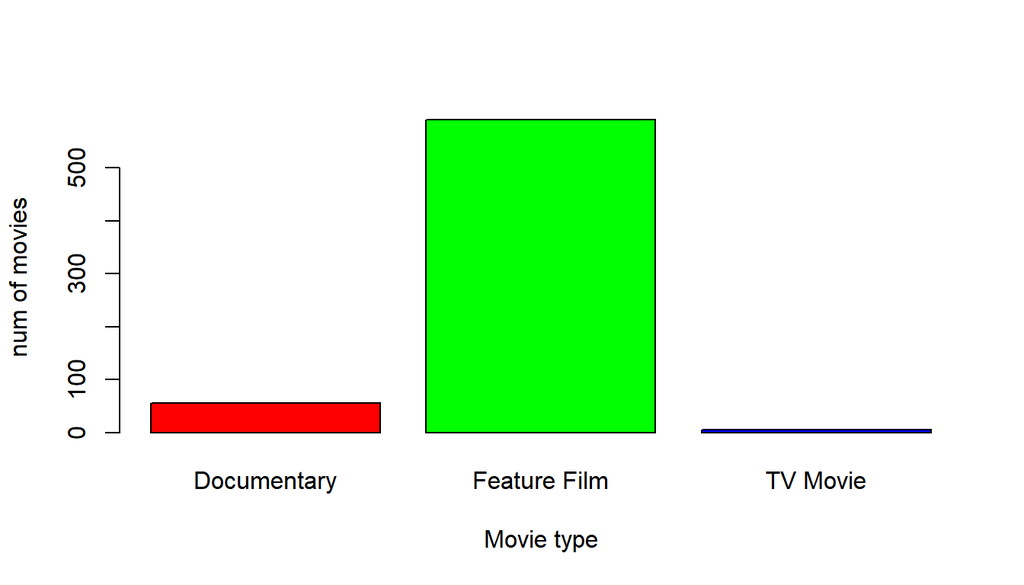

```r
plot(mv$title_type, ylab='num of movies', xlab='Movie type', col=rainbow((3)))
```

# genre (type)

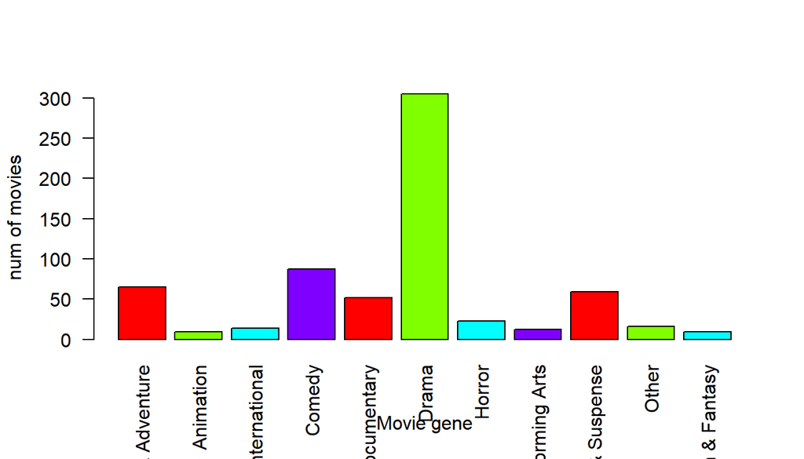

```r
plot(mv$genre, ylab='num of movies', xlab='Movie gene', col=rainbow((4)), axis = 0.01, las = 2)
```

# mpaa_rating (type)

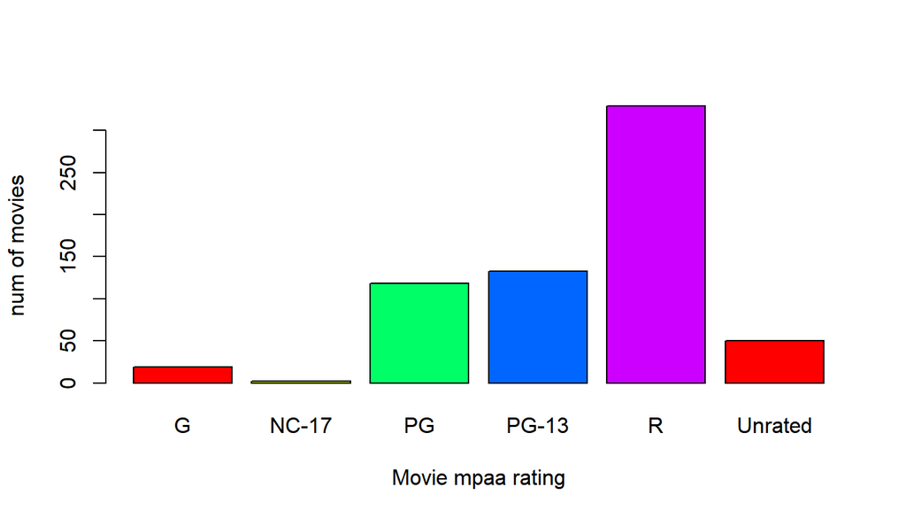

```r
plot(mv$mpaa_rating, ylab='num of movies', xlab='Movie mpaa rating', col=rainbow((5)))
```

# critics_rating (popularity)

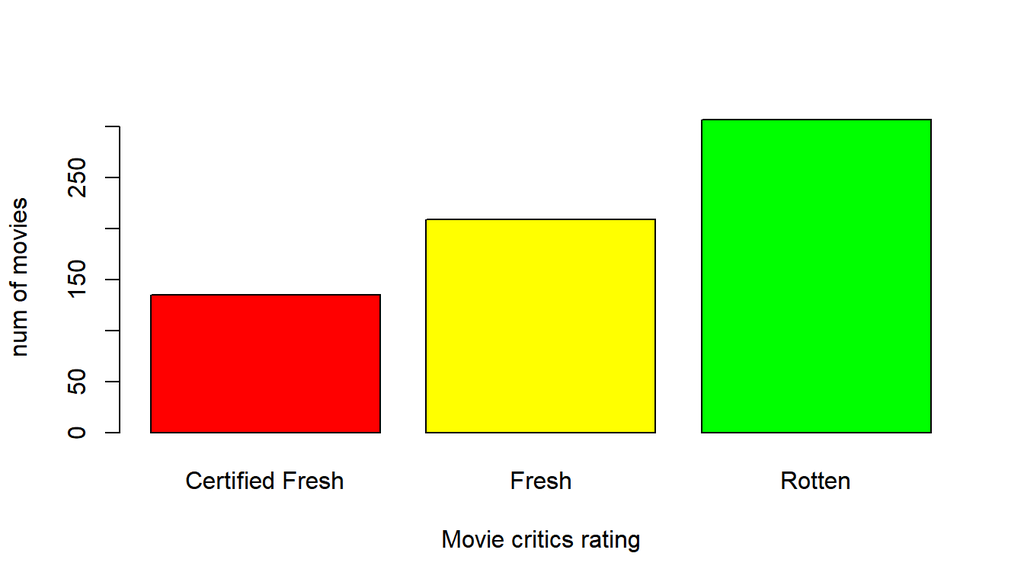

```r
plot(mv$critics_rating, ylab='num of movies', xlab='Movie critics rating', col=rainbow((6)))
```

# audience_rating (popularity)

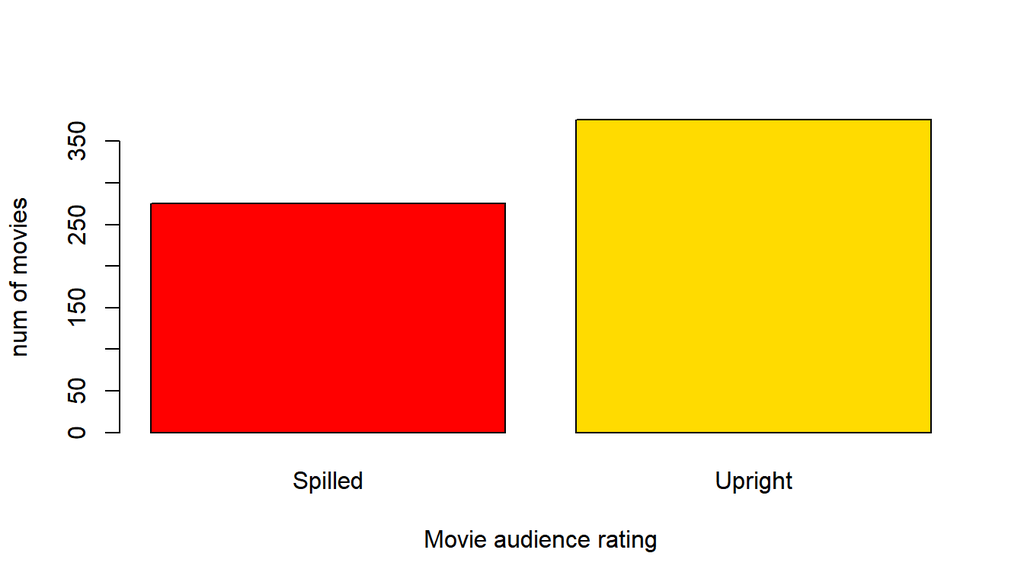

```r
plot(mv$audience_rating, ylab='num of movies', xlab='Movie audience rating', col=rainbow((7)))
```

# best_pic_nom (popularity)

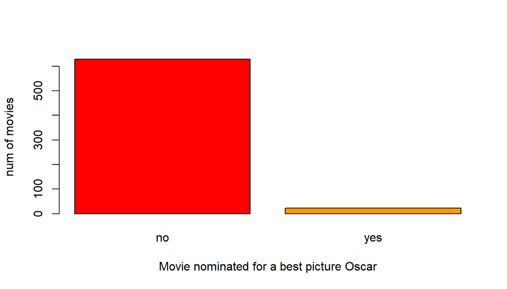

```r
plot(mv$best_pic_nom, ylab='num of movies', xlab='Movie nominated for a best picture Oscar', col=rainbow((10)))
```

# best_pic_win (popularity)

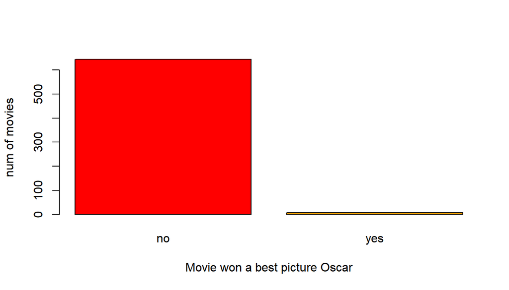

```r
plot(mv$best_pic_win, ylab='num of movies', xlab='Movie won a best picture Oscar', col=rainbow((10)))
```

## Part 4: Modeling

Model selection by backwards elimination using p-value

# Full model

```r
FM <- lm(audience_score ~
           imdb_rating+
           title_type+
           genre+
           mpaa_rating+
           critics_rating+
           audience_rating  +
           best_pic_nom+
           best_pic_win, data=mv
           )
summary(FM)
```

```
##
## Call:
## lm(formula = audience_score ~ imdb_rating + title_type + genre +
##     mpaa_rating + critics_rating + audience_rating + best_pic_nom +
##     best_pic_win, data = mv)
##
## Residuals:
##     Min      1Q  Median      3Q     Max
## -22.408  -4.434   0.448   4.368  24.829
##
## Coefficients:
##                                Estimate Std. Error t value Pr(>|t|)
## (Intercept)                    -10.7567     4.2334  -2.541   0.0113 *
## imdb_rating                      9.4383     0.4095  23.048   <2e-16 ***
## title_typeFeature Film           2.4689     2.5595   0.965   0.3351
## title_typeTV Movie               1.0011     4.0337   0.248   0.8041
## genreAnimation                   2.5258     2.6950   0.937   0.3490
## genreArt House & International  -2.5827     2.0816  -1.241   0.2152
## genreComedy                      1.6235     1.1412   1.423   0.1553
## genreDocumentary                 2.4988     2.7417   0.911   0.3624
## genreDrama                      -0.7871     0.9921  -0.793   0.4279
## genreHorror                     -1.4803     1.7116  -0.865   0.3875
## genreMusical & Performing Arts   3.4463     2.3478   1.468   0.1426
## genreMystery & Suspense         -3.0904     1.2858  -2.403   0.0165 *
## genreOther                      -0.2869     1.9635  -0.146   0.8839
## genreScience Fiction & Fantasy  -0.2517     2.4595  -0.102   0.9185
## mpaa_ratingNC-17                -0.6622     5.2154  -0.127   0.8990
## mpaa_ratingPG                   -0.4707     1.8890  -0.249   0.8033
## mpaa_ratingPG-13                -1.4845     1.9271  -0.770   0.4414
## mpaa_ratingR                    -1.4951     1.8686  -0.800   0.4239
## mpaa_ratingUnrated              -0.8771     2.1446  -0.409   0.6827
## critics_ratingFresh             -0.1115     0.8052  -0.138   0.8899
## critics_ratingRotten            -1.2935     0.9164  -1.412   0.1586
## audience_ratingUpright          20.1128     0.7883  25.515   <2e-16 ***
## best_pic_nomyes                  3.1906     1.7642   1.809   0.0710 .
## best_pic_winyes                 -2.4352     2.9945  -0.813   0.4164
## ---
## Signif. codes:  0 '***' 0.001 '**' 0.01 '*' 0.05 '.' 0.1 ' ' 1
##
## Residual standard error: 6.871 on 627 degrees of freedom
## Multiple R-squared:  0.8887, Adjusted R-squared:  0.8846
## F-statistic: 217.6 on 23 and 627 DF,  p-value: < 2.2e-16
```

```r
# Multiple R-squared:  0.8887,  Adjusted R-squared:  0.8846

# Coefficients:
#                                Estimate Std. Error t value Pr(>|t|)
# title_typeFeature Film           2.4689     2.5595   0.965   0.3351
# title_typeTV Movie               1.0011     4.0337   0.248   0.8041
```

# Full model with removing variable title_type

```r
FM_2 <- lm(audience_score ~
           imdb_rating+
           genre+
           mpaa_rating+
           critics_rating+
           audience_rating  +
           best_pic_nom+
           best_pic_win, data=mv
           )
summary(FM_2)
```

```
##
## Call:
## lm(formula = audience_score ~ imdb_rating + genre + mpaa_rating +
##     critics_rating + audience_rating + best_pic_nom + best_pic_win,
##     data = mv)
##
## Residuals:
##      Min       1Q   Median       3Q      Max
## -22.4321  -4.4248   0.4635   4.3447  24.8063
##
## Coefficients:
##                                Estimate Std. Error t value Pr(>|t|)
## (Intercept)                     -8.3304     3.3424  -2.492   0.0129 *
## imdb_rating                      9.4370     0.4081  23.124   <2e-16 ***
## genreAnimation                   2.5649     2.6929   0.952   0.3412
## genreArt House & International  -2.4926     2.0783  -1.199   0.2309
## genreComedy                      1.5620     1.1385   1.372   0.1705
## genreDocumentary                 0.3683     1.5568   0.237   0.8131
## genreDrama                      -0.7832     0.9904  -0.791   0.4294
## genreHorror                     -1.4594     1.7101  -0.853   0.3937
## genreMusical & Performing Arts   2.6963     2.2108   1.220   0.2231
## genreMystery & Suspense         -3.0807     1.2849  -2.398   0.0168 *
## genreOther                      -0.3448     1.9523  -0.177   0.8598
## genreScience Fiction & Fantasy  -0.2389     2.4577  -0.097   0.9226
## mpaa_ratingNC-17                -0.5948     5.2113  -0.114   0.9092
## mpaa_ratingPG                   -0.4266     1.8871  -0.226   0.8212
## mpaa_ratingPG-13                -1.4273     1.9249  -0.742   0.4587
## mpaa_ratingR                    -1.4532     1.8668  -0.778   0.4366
## mpaa_ratingUnrated              -1.0912     2.1314  -0.512   0.6089
## critics_ratingFresh             -0.1283     0.8037  -0.160   0.8732
## critics_ratingRotten            -1.2689     0.9150  -1.387   0.1660
## audience_ratingUpright          20.0899     0.7873  25.518   <2e-16 ***
## best_pic_nomyes                  3.2238     1.7627   1.829   0.0679 .
## best_pic_winyes                 -2.4279     2.9921  -0.811   0.4174
## ---
## Signif. codes:  0 '***' 0.001 '**' 0.01 '*' 0.05 '.' 0.1 ' ' 1
##
## Residual standard error: 6.866 on 629 degrees of freedom
## Multiple R-squared:  0.8885, Adjusted R-squared:  0.8847
## F-statistic: 238.6 on 21 and 629 DF,  p-value: < 2.2e-16
```

```r
# Multiple R-squared:  0.8885,  Adjusted R-squared:  0.8847

# Coefficients:
#                                Estimate Std. Error t value Pr(>|t|)
# mpaa_ratingNC-17                -0.5948     5.2113  -0.114   0.9092
# mpaa_ratingPG                   -0.4266     1.8871  -0.226   0.8212
# mpaa_ratingPG-13                -1.4273     1.9249  -0.742   0.4587
# mpaa_ratingR                    -1.4532     1.8668  -0.778   0.4366
# mpaa_ratingUnrated              -1.0912     2.1314  -0.512   0.6089
```

# Full model with removing variable title_type and mpaa_rating

```r
FM_3 <- lm(audience_score ~
           imdb_rating+
           genre+
           critics_rating+
           audience_rating  +
           best_pic_nom+
           best_pic_win, data=mv
           )
summary(FM_3)
```

```
##
## Call:
## lm(formula = audience_score ~ imdb_rating + genre + critics_rating +
##     audience_rating + best_pic_nom + best_pic_win, data = mv)
##
## Residuals:
##      Min       1Q   Median       3Q      Max
## -21.5495  -4.5477   0.5692   4.3712  24.6712
##
## Coefficients:
##                                Estimate Std. Error t value Pr(>|t|)
## (Intercept)                    -9.41602    2.78944  -3.376 0.000782 ***
## imdb_rating                     9.44335    0.40633  23.241  < 2e-16 ***
## genreAnimation                  3.43043    2.45298   1.398 0.162459
## genreArt House & International -2.78047    2.03040  -1.369 0.171354
## genreComedy                     1.39572    1.12728   1.238 0.216128
## genreDocumentary                0.31178    1.37883   0.226 0.821179
## genreDrama                     -1.07109    0.96401  -1.111 0.266956
## genreHorror                    -1.79071    1.66932  -1.073 0.283806
## genreMusical & Performing Arts  2.53641    2.19090   1.158 0.247422
## genreMystery & Suspense        -3.45580    1.25154  -2.761 0.005925 **
## genreOther                     -0.34704    1.93941  -0.179 0.858042
## genreScience Fiction & Fantasy -0.19022    2.44986  -0.078 0.938134
## critics_ratingFresh            -0.02791    0.79850  -0.035 0.972131
## critics_ratingRotten           -1.23580    0.90773  -1.361 0.173866
## audience_ratingUpright         20.10591    0.78414  25.641  < 2e-16 ***
## best_pic_nomyes                 3.23956    1.75260   1.848 0.065005 .
## best_pic_winyes                -2.29545    2.98237  -0.770 0.441780
## ---
## Signif. codes:  0 '***' 0.001 '**' 0.01 '*' 0.05 '.' 0.1 ' ' 1
##
## Residual standard error: 6.851 on 634 degrees of freedom
## Multiple R-squared:  0.888,  Adjusted R-squared:  0.8852
## F-statistic: 314.3 on 16 and 634 DF,  p-value: < 2.2e-16
```

```r
# Multiple R-squared:  0.888,   Adjusted R-squared:  0.8852

# Coefficients:
#                                Estimate Std. Error t value Pr(>|t|)
# best_pic_winyes                -2.29545    2.98237  -0.770 0.441780
```

# Full model with removing variable title_type, mpaa_rating and best_pic_win

```r
FM_4 <- lm(audience_score ~
           imdb_rating+
           genre+
           critics_rating+
           audience_rating  +
           best_pic_nom
           , data=mv
           )
summary(FM_4)
```

```
##
## Call:
## lm(formula = audience_score ~ imdb_rating + genre + critics_rating +
##     audience_rating + best_pic_nom, data = mv)
##
## Residuals:
##      Min       1Q   Median       3Q      Max
## -21.5616  -4.5112   0.5653   4.3777  24.6465
##
## Coefficients:
##                                Estimate Std. Error t value Pr(>|t|)
## (Intercept)                    -9.40842    2.78853  -3.374 0.000786 ***
## imdb_rating                     9.43436    0.40603  23.236  < 2e-16 ***
## genreAnimation                  3.43643    2.45218   1.401 0.161590
## genreArt House & International -2.77561    2.02974  -1.367 0.171962
## genreComedy                     1.37390    1.12656   1.220 0.223091
## genreDocumentary                0.32514    1.37828   0.236 0.813582
## genreDrama                     -1.06861    0.96370  -1.109 0.267910
## genreHorror                    -1.79250    1.66879  -1.074 0.283171
## genreMusical & Performing Arts  2.54941    2.19014   1.164 0.244843
## genreMystery & Suspense        -3.47264    1.25095  -2.776 0.005665 **
## genreOther                     -0.26710    1.93600  -0.138 0.890312
## genreScience Fiction & Fantasy -0.18870    2.44908  -0.077 0.938609
## critics_ratingFresh             0.02682    0.79507   0.034 0.973099
## critics_ratingRotten           -1.18979    0.90547  -1.314 0.189320
## audience_ratingUpright         20.11754    0.78375  25.668  < 2e-16 ***
## best_pic_nomyes                 2.64520    1.57280   1.682 0.093090 .
## ---
## Signif. codes:  0 '***' 0.001 '**' 0.01 '*' 0.05 '.' 0.1 ' ' 1
##
## Residual standard error: 6.849 on 635 degrees of freedom
## Multiple R-squared:  0.8879, Adjusted R-squared:  0.8853
## F-statistic: 335.5 on 15 and 635 DF,  p-value: < 2.2e-16
```

```r
# Multiple R-squared:  0.8879,  Adjusted R-squared:  0.8853
```

# Analyze the final model

```r
summary(FM_4)
```

```
##
## Call:
## lm(formula = audience_score ~ imdb_rating + genre + critics_rating +
##     audience_rating + best_pic_nom, data = mv)
##
## Residuals:
##      Min       1Q   Median       3Q      Max
## -21.5616  -4.5112   0.5653   4.3777  24.6465
##
## Coefficients:
##                                Estimate Std. Error t value Pr(>|t|)
## (Intercept)                    -9.40842    2.78853  -3.374 0.000786 ***
## imdb_rating                     9.43436    0.40603  23.236  < 2e-16 ***
## genreAnimation                  3.43643    2.45218   1.401 0.161590
## genreArt House & International -2.77561    2.02974  -1.367 0.171962
## genreComedy                     1.37390    1.12656   1.220 0.223091
## genreDocumentary                0.32514    1.37828   0.236 0.813582
## genreDrama                     -1.06861    0.96370  -1.109 0.267910
## genreHorror                    -1.79250    1.66879  -1.074 0.283171
## genreMusical & Performing Arts  2.54941    2.19014   1.164 0.244843
## genreMystery & Suspense        -3.47264    1.25095  -2.776 0.005665 **
## genreOther                     -0.26710    1.93600  -0.138 0.890312
## genreScience Fiction & Fantasy -0.18870    2.44908  -0.077 0.938609
## critics_ratingFresh             0.02682    0.79507   0.034 0.973099
## critics_ratingRotten           -1.18979    0.90547  -1.314 0.189320
## audience_ratingUpright         20.11754    0.78375  25.668  < 2e-16 ***
## best_pic_nomyes                 2.64520    1.57280   1.682 0.093090 .
## ---
## Signif. codes:  0 '***' 0.001 '**' 0.01 '*' 0.05 '.' 0.1 ' ' 1
##
## Residual standard error: 6.849 on 635 degrees of freedom
## Multiple R-squared:  0.8879, Adjusted R-squared:  0.8853
## F-statistic: 335.5 on 15 and 635 DF,  p-value: < 2.2e-16
```

```r
anova(FM_4)
```

```
## Analysis of Variance Table
##
## Response: audience_score
##                  Df Sum Sq Mean Sq   F value    Pr(>F)
## imdb_rating       1 198831  198831 4238.7072 < 2.2e-16 ***
## genre            10   4561     456    9.7228 3.347e-15 ***
## critics_rating    2   1630     815   17.3705 4.521e-08 ***
## audience_rating   1  30879   30879  658.2784 < 2.2e-16 ***
## best_pic_nom      1    133     133    2.8286   0.09309 .
## Residuals       635  29787      47
## ---
## Signif. codes:  0 '***' 0.001 '**' 0.01 '*' 0.05 '.' 0.1 ' ' 1
```

```r
coefficients(FM_4)
```

```
##                    (Intercept)                    imdb_rating
##                    -9.40841619                     9.43436475
##                 genreAnimation genreArt House & International
##                     3.43642909                    -2.77560774
##                    genreComedy               genreDocumentary
##                     1.37389504                     0.32514270
##                     genreDrama                    genreHorror
##                    -1.06860556                    -1.79249721
## genreMusical & Performing Arts        genreMystery & Suspense
##                     2.54941484                    -3.47263563
##                     genreOther genreScience Fiction & Fantasy
##                    -0.26709913                    -0.18869796
##            critics_ratingFresh           critics_ratingRotten
##                     0.02682201                    -1.18978631
##         audience_ratingUpright                best_pic_nomyes
##                    20.11753758                     2.64520489
```

## Model Diagnostics i.e. Checking the conditions graphically

# Check for linearity

Checking for the linear reationship between numerical predictors and residuals

```r
plot(FM_4$residuals ~ mv$imdb_rating, main='Linearity Condition')
```

[output not shown]

No descernable pattern

# Check for normality

```r
qqnorm(FM_4$residual, main='Normality Condition')
qqline(FM_4$residual, main='Normality Condition')
```

[output not shown]

The majority of the points lie on the line and no appaeent outliners

```r
hist(FM_4$residuals, prob=TRUE, main="Normality Condition")
lines(density(FM_4$residuals), col="darkblue", lwd=5)
```

[output not shown]

Nearly normal distribution

# Check for variability

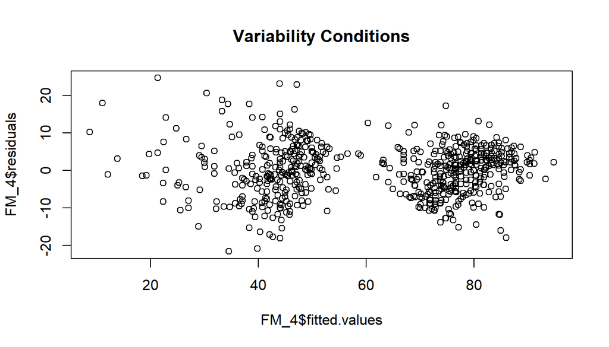

```r
plot(FM_4$residuals ~ FM_4$fitted.values, main='Variability Conditions')
```

```r
plot(abs(FM_4$residuals) ~ FM_4$fitted.values, main='Variability Conditions')
```

[output not shown]

No visibls fan pattern

# Check for independancy

```r
plot(FM_4$residuals, main='Independany Conditions')
```

[output not shown]

Randomly scatterd around zero

## Part 5: Prediction

The model can now be used to predict the auidence score of a movie. The chosen test movie is Avengers:Endgame (2019).

```r
endgame = data.frame(genre = 'Action & Adventure',
                     mpaa_rating = 'PG-13',
                     imdb_rating = 8.7,
                     imdb_num_votes = 487015,
                     best_pic_nom = 'no',
                     best_pic_win = 'no',
                     top200_box = 'yes',
                     audience_rating <- "Upright",
                     critics_rating <- "Fresh",
                     audience_score <- 91)
```

# Predicting the audience score

```r
myPrediction <- round(predict(FM_4, endgame), digits = 0)
c(myPrediction, endgame$audience_score)
```

```
##  1
## 93 91
```

# Estimate and interpret the prediction confidence interval

```r
ConfidenceInterval <- predict(FM_4, endgame, interval="confidence")
ConfidenceInterval
```

```
##        fit      lwr      upr
## 1 92.81492 90.36751 95.26232
```

: 95% confident that, all else being equal, the predicted audience score for the movie ‘Avengers:Endgame’ will be between 90.37 and 95.26 on average.

## Part 6: Conclusion

Explanatory data analysis was of great help in providing the insight on what data items to include in the model or not to. The modeling methodology of evaluating both significance and variablity of each predictor. The model that very precisely answered the research question and the model predicted the audience score correctly. The actual audience score of Avengers:Endgame is 91 and it is placed between 90.37 and 95.26.